# Savvy Parity Regression Model Estimation with ‘savvyPR’

```r
library(savvyPR)
library(ggplot2)
```

# Introduction

This vignette demonstrates how to use the `savvyPR` package for parity regression model estimation and cross-validation. The package handles multicollinearity by applying risk parity constraints, supporting both Budget-based and Target-based parameterizations.

# Installation

```r
# Install the development version from GitHub
# devtools::install_github("Ziwei-ChenChen/savvyPR)
library(savvyPR)
library(MASS)
library(glmnet)
```

# Parity Regression Model Estimation

The `savvyPR` function is used to fit a parity regression model. Here we demonstrate its usage with synthetic, highly correlated data.

```r
library(MASS)
library(glmnet)

# Function to create a correlation matrix for X
create_corr_matrix <- function(rho, p) {
  corr_matrix <- diag(1, p)
  for (i in 2:p) {
    for (j in 1:(i-1)) {
      corr_matrix[i, j] <- rho^(abs(i - j))
      corr_matrix[j, i] <- corr_matrix[i, j] # symmetric matrix
    }
  }
  return(corr_matrix)
}

# Function to generate beta values with both positive and negative signs
generate_beta <- function(p) {
  half_p <- ceiling(p / 2)
  beta <- rep(c(1, -1), length.out = p) * rep(1:half_p, each = 2)[1:p]
  return(beta)
}

set.seed(123)
n <- 1500
p <- 15
rho <- -0.5

corr_matrix <- create_corr_matrix(rho, p)
x <- mvrnorm(n = n, mu = rep(0, p), Sigma = corr_matrix)
beta <- generate_beta(p + 1)
sigma_vec <- abs(rnorm(n = n, mean = 15, sd = sqrt(1)))
y <- rnorm(n, mean = as.vector(cbind(1,x)%*%beta), sd = sigma_vec)

# 1. Run OLS estimation with intercept
result_ols <- lm(y ~ x)
coef_ols <- coef(result_ols)

# 2. Run Ridge Regression (RR) estimation
result_RR <- glmnet(x, y, alpha = 0, lambda = 1)
coef_RR <- coef(result_RR)

# 3. Run PR estimation (Budget Method)
result_pr_budget <- savvyPR(x, y, method = "budget", val = 0.05, intercept = TRUE)
print(result_pr_budget)
```

```
##
## Call:  savvyPR(x = x, y = y, method = "budget", val = 0.05, intercept = TRUE)
##
##  Method Number of Non-Zero Coefficients Intercept Included Lambda Value
##  budget                              16                Yes           NA
##
## Coefficients:
##  Coefficient Estimate
##  (Intercept)   0.9474
##           X1  -3.6223
##           X2   3.7272
##           X3  -3.4870
##           X4   4.1283
##           X5  -4.1596
##           X6   5.1385
##           X7  -4.9644
##           X8   6.0606
##           X9  -6.0015
##          X10   6.3743
##          X11  -5.6775
##          X12   7.8006
##          X13  -7.3068
##          X14   9.0372
##          X15  -8.7735
```

```r
coef_pr_budget <- coef(result_pr_budget)

# 4. Run PR estimation (Target Method)
result_pr_target <- savvyPR(x, y, method = "target", val = 1, intercept = TRUE)
print(result_pr_target)
```

```
##
## Call:  savvyPR(x = x, y = y, method = "target", val = 1, intercept = TRUE)
##
##  Method Number of Non-Zero Coefficients Intercept Included Lambda Value
##  target                              16                Yes           NA
##
## Coefficients:
##  Coefficient Estimate
##  (Intercept)   0.9978
##           X1  -4.1012
##           X2   4.1303
##           X3  -3.8591
##           X4   4.4168
##           X5  -4.5009
##           X6   5.4143
##           X7  -5.2861
##           X8   6.2761
##           X9  -6.2403
##          X10   6.5827
##          X11  -5.9788
##          X12   7.9785
##          X13  -7.5766
##          X14   9.2430
##          X15  -9.0638
```

```r
coef_pr_target <- coef(result_pr_target)

# Calculate the L2 distance to true beta
ols_L2 <- sqrt(sum((beta - coef_ols)^2))
print(paste("OLS L2:", ols_L2))
```

```
## [1] "OLS L2: 2.24654287653346"
```

```r
RR_L2 <- sqrt(sum((beta - coef_RR)^2))
print(paste("Ridge L2:", RR_L2))
```

```
## [1] "Ridge L2: 2.10076303047981"
```

```r
pr_budget_L2 <- sqrt(sum((beta - coef_pr_budget)^2))
print(paste("PR Budget L2:", pr_budget_L2))
```

```
## [1] "PR Budget L2: 4.6582202853575"
```

```r
pr_target_L2 <- sqrt(sum((beta - coef_pr_target)^2))
print(paste("PR Target L2:", pr_target_L2))
```

```
## [1] "PR Target L2: 5.74454449168347"
```

You can use the `summary` function to get detailed statistics for your models:

```r
summary(result_pr_budget)
```

```
## Summary of Parity Model
## ===================================================================
##
## Parameterization Method: budget
## Intercept: Included
##
## Call:
## savvyPR(x = x, y = y, method = "budget", val = 0.05, intercept = TRUE)
##
## Residuals:
##          0%         25%         50%         75%        100%
## -56.4721096 -10.9724126  -0.1952992  10.8910982  48.9682405
##
## Coefficients:
##             Estimate Std. Error t value  Pr(>|t|)   2.5 %   97.5 %  Signif.
## (Intercept) 0.9474   0.431      2.1984   0.0281     0.1028  1.7921  *
## X1          -3.6223  0.5026     -7.2072  9.0577e-13 -4.6073 -2.6372 ***
## X2          3.7272   0.5477     6.8045   1.4663e-11 2.6536  4.8007  ***
## X3          -3.487   0.5593     -6.2346  5.8903e-10 -4.5832 -2.3908 ***
## X4          4.1283   0.55       7.5065   1.0423e-13 3.0504  5.2062  ***
## X5          -4.1596  0.5612     -7.4125  2.0734e-13 -5.2595 -3.0598 ***
## X6          5.1385   0.5528     9.2957   5.0478e-20 4.0551  6.2219  ***
## X7          -4.9644  0.5569     -8.914   1.4106e-18 -6.056  -3.8729 ***
## X8          6.0606   0.5498     11.0227  3.2671e-27 4.983   7.1383  ***
## X9          -6.0015  0.5598     -10.7216 6.9524e-26 -7.0986 -4.9044 ***
## X10         6.3743   0.5607     11.3678  9.0139e-29 5.2753  7.4733  ***
## X11         -5.6775  0.5529     -10.2685 6.0457e-24 -6.7612 -4.5938 ***
## X12         7.8006   0.5748     13.5718  1.2278e-39 6.6741  8.9272  ***
## X13         -7.3068  0.5552     -13.1595 1.7263e-37 -8.3951 -6.2185 ***
## X14         9.0372   0.5627     16.059   1.2454e-53 7.9342  10.1401 ***
## X15         -8.7735  0.4755     -18.4495 1.3655e-68 -9.7056 -7.8415 ***
## ---
## Signif. codes:  0 '***' 0.001 '**' 0.01 '*' 0.05 '.' 0.1 ' ' 1
##
## Residual standard error: 16.6436 on 1484 degrees of freedom
## Multiple R-squared: 0.7826 , Adjusted R-squared: 0.7804
## F-statistic: 356.1532 on 15 and 1484 DF,  p-value: 0.0000e+00
## AIC: 8451.993 , BIC: 8537.004 , Deviance: 411082.4
```

```r
summary(result_pr_target)
```

```
## Summary of Parity Model
## ===================================================================
##
## Parameterization Method: target
## Intercept: Included
##
## Call:
## savvyPR(x = x, y = y, method = "target", val = 1, intercept = TRUE)
##
## Residuals:
##          0%         25%         50%         75%        100%
## -58.9781373 -11.4050252  -0.2897816  11.4442435  52.0560037
##
## Coefficients:
##             Estimate Std. Error t value  Pr(>|t|)   2.5 %    97.5 %  Signif.
## (Intercept) 0.9978   0.4524     2.2056   0.0276     0.1111   1.8844  *
## X1          -4.1012  0.5276     -7.7736  1.4166e-14 -5.1352  -3.0671 ***
## X2          4.1303   0.575      7.1833   1.0728e-12 3.0033   5.2572  ***
## X3          -3.8591  0.5871     -6.5731  6.8054e-11 -5.0098  -2.7084 ***
## X4          4.4168   0.5773     7.6507   3.5751e-14 3.2853   5.5484  ***
## X5          -4.5009  0.5891     -7.6408  3.8518e-14 -5.6555  -3.3464 ***
## X6          5.4143   0.5803     9.3308   3.6947e-20 4.277    6.5516  ***
## X7          -5.2861  0.5846     -9.042   4.6833e-19 -6.4319  -4.1402 ***
## X8          6.2761   0.5772     10.8739  1.4943e-26 5.1448   7.4073  ***
## X9          -6.2403  0.5876     -10.6202 1.9152e-25 -7.392   -5.0887 ***
## X10         6.5827   0.5886     11.1835  6.2051e-28 5.4291   7.7364  ***
## X11         -5.9788  0.5804     -10.3013 4.4033e-24 -7.1163  -4.8412 ***
## X12         7.9785   0.6033     13.2239  8.0385e-38 6.796    9.1611  ***
## X13         -7.5766  0.5829     -12.9991 1.1453e-36 -8.7189  -6.4342 ***
## X14         9.243    0.5907     15.647   3.3967e-51 8.0853   10.4008 ***
## X15         -9.0638  0.4992     -18.1572 1.0869e-66 -10.0422 -8.0854 ***
## ---
## Signif. codes:  0 '***' 0.001 '**' 0.01 '*' 0.05 '.' 0.1 ' ' 1
##
## Residual standard error: 17.4711 on 1484 degrees of freedom
## Multiple R-squared: 0.7605 , Adjusted R-squared: 0.758
## F-statistic: 314.0652 on 15 and 1484 DF,  p-value: 0.0000e+00
## AIC: 8597.558 , BIC: 8682.57 , Deviance: 452975.2
```

The package also provides built-in plotting functions to visualize the coefficients and the risk parity optimization distributions.

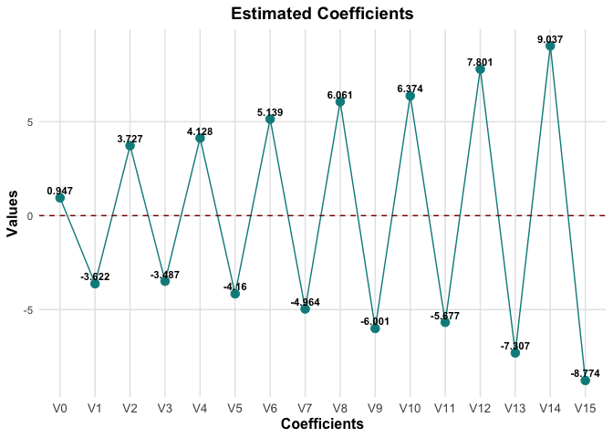

```r
# Plot the estimated coefficients
plot(result_pr_budget, plot_type = "estimated_coefficients", label = TRUE)
```

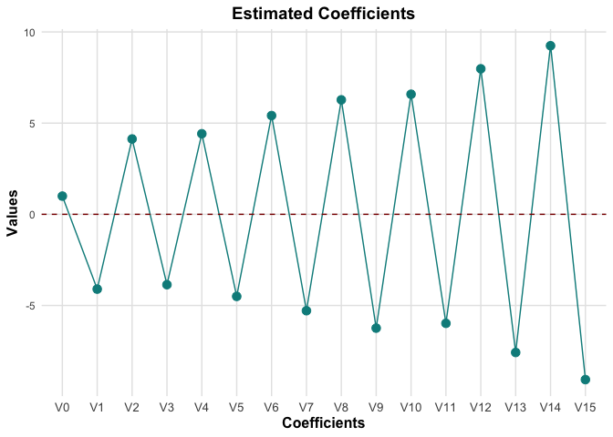

```r
plot(result_pr_target, plot_type = "estimated_coefficients", label = FALSE)
```

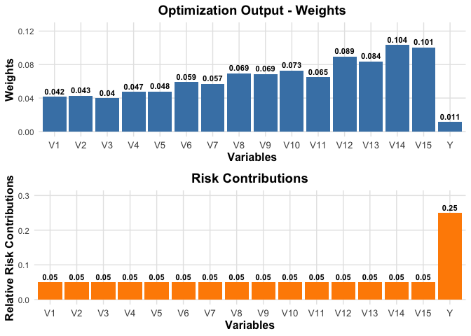

```r
# Plot the risk contributions and weights/target variables
plot(result_pr_budget, plot_type = "risk_contributions", label = TRUE)
```

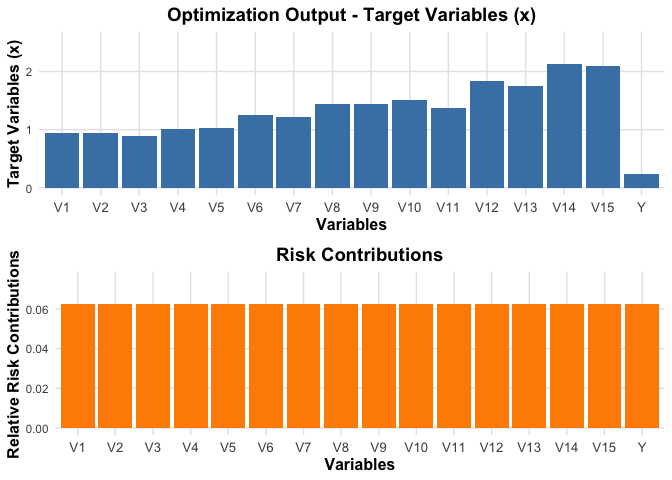

```r
plot(result_pr_target, plot_type = "risk_contributions", label = FALSE)
```

# Cross-Validation for Parity Regression Models

The `cv.savvyPR` function performs cross-validation to select optimal parameters. It handles both the “budget” sequence and the “target” sequence automatically.

```r
# Cross-validation with Ridge
result_rr_cv <- cv.glmnet(x, y, alpha = 0, folds = 5)
fit_rr1 <- glmnet(x, y, alpha = 0, lambda = result_rr_cv$lambda.min)
coef_rr_cv <- coef(fit_rr1)[,1]

# Cross-validation with model type PR1 (Budget Method)
result_pr_cv1 <- cv.savvyPR(x, y, method = "budget", folds = 5, model_type = "PR1", measure_type = "mse")
coef_pr_cv1 <- coef(result_pr_cv1)

# Cross-validation with model type PR2 (Target Method)
result_pr_cv2 <- cv.savvyPR(x, y, method = "target", folds = 5, model_type = "PR2", measure_type = "mse")
coef_pr_cv2 <- coef(result_pr_cv2)

# Cross-validation with model type PR3 (Budget Method)
result_pr_cv3 <- cv.savvyPR(x, y, method = "budget", folds = 5, model_type = "PR3", measure_type = "mse")
coef_pr_cv3 <- coef(result_pr_cv3)

# Calculate the L2 distance
print(paste("Ridge CV L2:", sqrt(sum((beta - coef_rr_cv)^2))))
```

```
## [1] "Ridge CV L2: 2.02357341480252"
```

```r
print(paste("PR1 CV (Budget) L2:", sqrt(sum((beta - coef_pr_cv1)^2))))
```

```
## [1] "PR1 CV (Budget) L2: 2.13653233706683"
```

```r
print(paste("PR2 CV (Target) L2:", sqrt(sum((beta - coef_pr_cv2)^2))))
```

```
## [1] "PR2 CV (Target) L2: 2.13123848154008"
```

```r
print(paste("PR3 CV (Budget) L2:", sqrt(sum((beta - coef_pr_cv3)^2))))
```

```
## [1] "PR3 CV (Budget) L2: 1.95028924294646"
```

We can summarize the cross-validation results to see the optimal tuning values chosen by the algorithm.

```r
summary(result_pr_cv1)
```

```
## Summary of Cross-Validated Parity Model
## ===================================================================
##
## Parameterization Method: budget
## Intercept: Included
##
## Call:
## cv.savvyPR(x = x, y = y, method = "budget", folds = 5, model_type = "PR1",
##     measure_type = "mse")
##
## Residuals:
##          0%         25%         50%         75%        100%
## -48.7354673 -10.2964301  -0.2204747  10.6115532  52.7232048
##
## Coefficients:
##             Estimate Std. Error t value  Pr(>|t|)   2.5 %   97.5 %  Signif.
## (Intercept) 0.7757   0.3938     1.9699   0.0490     0.0039  1.5476  *
## X1          -1.4127  0.4593     -3.0759  0.0021     -2.3128 -0.5125 **
## X2          2.366    0.5005     4.727    2.4950e-06 1.385   3.347   ***
## X3          -1.7786  0.5111     -3.4801  0.0005     -2.7803 -0.7769 ***
## X4          3.533    0.5026     7.0302   3.1358e-12 2.5481  4.518   ***
## X5          -2.7157  0.5128     -5.296   1.3616e-07 -3.7208 -1.7107 ***
## X6          4.5448   0.5051     8.9974   6.8876e-19 3.5548  5.5348  ***
## X7          -3.7245  0.5089     -7.3185  4.0907e-13 -4.7219 -2.727  ***
## X8          5.5978   0.5024     11.1415  9.5942e-28 4.6131  6.5826  ***
## X9          -5.2052  0.5115     -10.1763 1.4707e-23 -6.2077 -4.2027 ***
## X10         5.9252   0.5124     11.5639  1.1254e-29 4.921   6.9295  ***
## X11         -4.5194  0.5052     -8.9451  1.0806e-18 -5.5096 -3.5291 ***
## X12         7.4844   0.5252     14.2501  2.7928e-43 6.455   8.5138  ***
## X13         -6.4236  0.5074     -12.6604 5.8619e-35 -7.4181 -5.4292 ***
## X14         8.5038   0.5142     16.537   1.6420e-56 7.496   9.5117  ***
## X15         -7.9255  0.4345     -18.2386 3.2262e-67 -8.7772 -7.0738 ***
## ---
## Signif. codes:  0 '***' 0.001 '**' 0.01 '*' 0.05 '.' 0.1 ' ' 1
##
## Residual standard error: 15.2088 on 1484 degrees of freedom
## Multiple R-squared: 0.8185 , Adjusted R-squared: 0.8166
## F-statistic: 446.0718 on 15 and 1484 DF,  p-value: 0.0000e+00
## AIC: 8181.532 , BIC: 8266.543 , Deviance: 343259.3
##
## Cross-Validation Summary:
## Mean Cross-Validation Error ( mse: Mean-Squared Error ): 234.5913
## Optimal Val: 0.002051
## Fixed Lambda: 0
```

```r
summary(result_pr_cv2)
```

```
## Summary of Cross-Validated Parity Model
## ===================================================================
##
## Parameterization Method: target
## Intercept: Included
##
## Call:
## cv.savvyPR(x = x, y = y, method = "target", folds = 5, model_type = "PR2",
##     measure_type = "mse")
##
## Residuals:
##          0%         25%         50%         75%        100%
## -49.3945508 -10.3670298  -0.2395204  10.7127881  54.4065137
##
## Coefficients:
##             Estimate Std. Error t value  Pr(>|t|)   2.5 %   97.5 %  Signif.
## (Intercept) 0.764    0.3937     1.9405   0.0525     -0.0077 1.5356  .
## X1          -1.1001  0.4592     -2.396   0.0167     -2.0001 -0.2002 *
## X2          2.3507   0.5004     4.6976   2.8764e-06 1.3699  3.3315  ***
## X3          -1.5982  0.511      -3.1279  0.0018     -2.5997 -0.5968 **
## X4          3.5608   0.5024     7.087    2.1112e-12 2.576   4.5455  ***
## X5          -2.605   0.5127     -5.0812  4.2258e-07 -3.6098 -1.6002 ***
## X6          4.4804   0.505      8.8718   2.0229e-18 3.4906  5.4702  ***
## X7          -3.6559  0.5088     -7.1855  1.0567e-12 -4.6531 -2.6587 ***
## X8          5.5172   0.5023     10.9836  4.8790e-27 4.5327  6.5017  ***
## X9          -5.1496  0.5114     -10.0701 4.0618e-23 -6.1519 -4.1474 ***
## X10         5.8444   0.5123     11.4088  5.8468e-29 4.8404  6.8485  ***
## X11         -4.4766  0.5051     -8.8625  2.1904e-18 -5.4666 -3.4866 ***
## X12         7.381    0.5251     14.0566  3.1557e-42 6.3518  8.4102  ***
## X13         -6.3708  0.5073     -12.5592 1.8691e-34 -7.365  -5.3766 ***
## X14         8.3905   0.5141     16.3204  3.3696e-55 7.3829  9.3982  ***
## X15         -7.7903  0.4344     -17.9316 3.0955e-65 -8.6418 -6.9388 ***
## ---
## Signif. codes:  0 '***' 0.001 '**' 0.01 '*' 0.05 '.' 0.1 ' ' 1
##
## Residual standard error: 15.2052 on 1484 degrees of freedom
## Multiple R-squared: 0.8186 , Adjusted R-squared: 0.8167
## F-statistic: 446.3271 on 15 and 1484 DF,  p-value: 0.0000e+00
## AIC: 8180.829 , BIC: 8265.841 , Deviance: 343098.6
##
## Cross-Validation Summary:
## Mean Cross-Validation Error ( mse: Mean-Squared Error ): 234.9548
## Optimal Val: 0
## Fixed Lambda: 0.7543
```

```r
summary(result_pr_cv3)
```

```
## Summary of Cross-Validated Parity Model
## ===================================================================
##
## Parameterization Method: budget
## Intercept: Included
##
## Call:
## cv.savvyPR(x = x, y = y, method = "budget", folds = 5, model_type = "PR3",
##     measure_type = "mse")
##
## Residuals:
##          0%         25%         50%         75%        100%
## -49.1703575 -10.3073085  -0.3193037  10.8172768  53.4727869
##
## Coefficients:
##             Estimate Std. Error t value  Pr(>|t|)   2.5 %   97.5 %  Signif.
## (Intercept) 0.7686   0.3939     1.9513   0.0512     -0.0034 1.5405  .
## X1          -1.4104  0.4593     -3.0704  0.0022     -2.3107 -0.5101 **
## X2          2.2843   0.5006     4.5631   5.4569e-06 1.3032  3.2655  ***
## X3          -1.8217  0.5112     -3.5638  0.0004     -2.8236 -0.8199 ***
## X4          3.4573   0.5026     6.8782   8.9074e-12 2.4721  4.4424  ***
## X5          -2.7309  0.5129     -5.3246  1.1674e-07 -3.7361 -1.7257 ***
## X6          4.4236   0.5052     8.7558   5.4115e-18 3.4334  5.4138  ***
## X7          -3.7275  0.509      -7.3232  3.9544e-13 -4.7252 -2.7299 ***
## X8          5.479    0.5025     10.903   1.1107e-26 4.4941  6.4639  ***
## X9          -5.1863  0.5116     -10.1376 2.1323e-23 -6.189  -4.1836 ***
## X10         5.803    0.5125     11.3233  1.4394e-28 4.7986  6.8075  ***
## X11         -4.5692  0.5053     -9.042   4.6805e-19 -5.5596 -3.5788 ***
## X12         7.2898   0.5253     13.8772  2.9219e-41 6.2602  8.3194  ***
## X13         -6.4111  0.5075     -12.6334 7.9892e-35 -7.4057 -5.4164 ***
## X14         8.3162   0.5143     16.1692  2.7349e-54 7.3081  9.3242  ***
## X15         -7.7702  0.4346     -17.8779 6.8380e-65 -8.622  -6.9183 ***
## ---
## Signif. codes:  0 '***' 0.001 '**' 0.01 '*' 0.05 '.' 0.1 ' ' 1
##
## Residual standard error: 15.2115 on 1484 degrees of freedom
## Multiple R-squared: 0.8184 , Adjusted R-squared: 0.8166
## F-statistic: 445.8784 on 15 and 1484 DF,  p-value: 0.0000e+00
## AIC: 8182.064 , BIC: 8267.075 , Deviance: 343381.1
##
## Cross-Validation Summary:
## Mean Cross-Validation Error ( mse: Mean-Squared Error ): 234.3193
## Fixed Val: 0.002051
## Optimal Lambda: 0.03728
```

We can also visualize the cross-validated models:

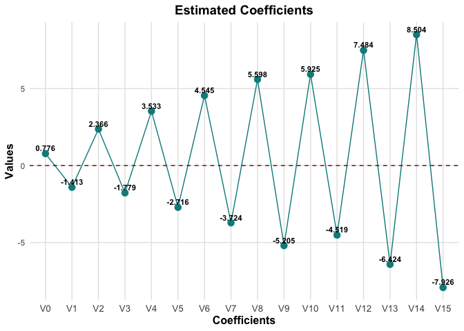

```r
# Plot coefficients and risk contributions for PR1
plot(result_pr_cv1, plot_type = "estimated_coefficients", label = TRUE)
```

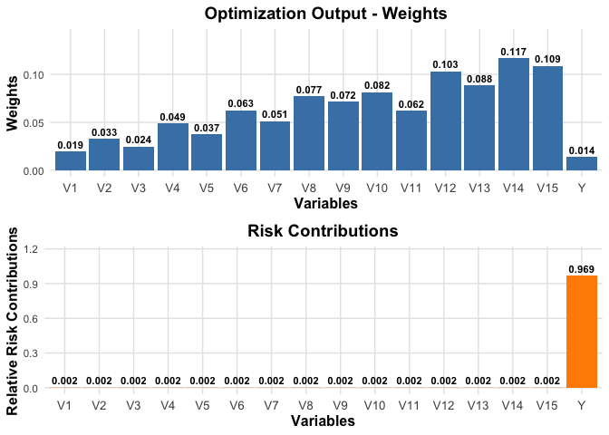

```r
plot(result_pr_cv1, plot_type = "risk_contributions",label = TRUE)
```

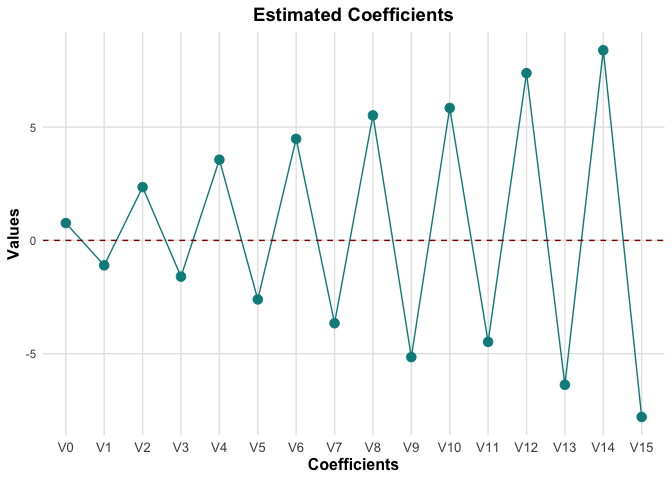

```r
# Plot coefficients and risk contributions for PR2
plot(result_pr_cv2, plot_type = "estimated_coefficients", label = FALSE)
```

```r
# Cannot plot risk-contribution for PR2 since the tuning parameter val=0 is fixed.
#plot(result_pr_cv2, plot_type = "risk_contributions", label = FALSE)
```

We can visualize the cross-validation error curves to see exactly where the optimal minimum was found.

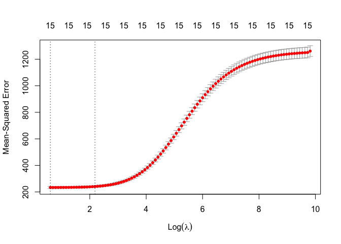

```r
# Plot the cross-validation errors for each model
plot(result_rr_cv)
```

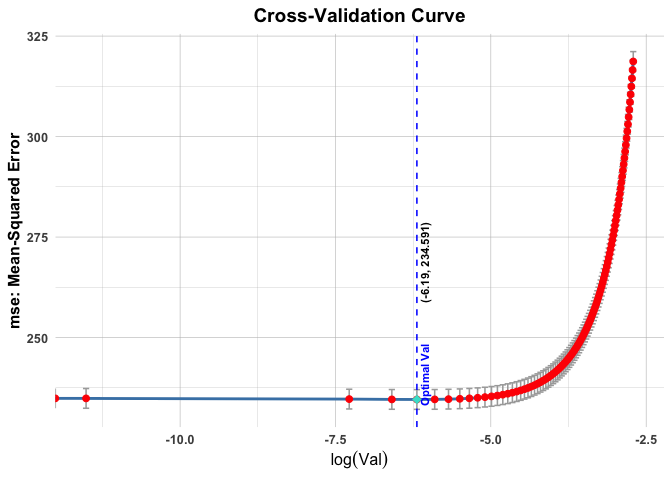

```r
plot(result_pr_cv1, plot_type = "cv_errors", label = TRUE)
```

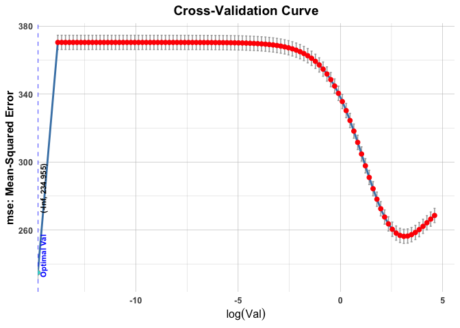

```r
plot(result_pr_cv2, plot_type = "cv_errors")
```

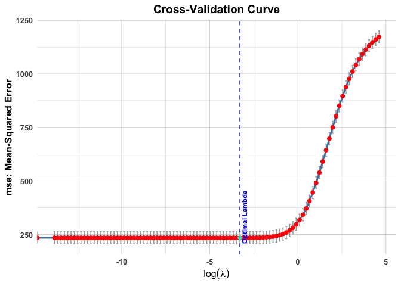

```r
plot(result_pr_cv3, plot_type = "cv_errors", label = FALSE)
```

Finally, we can plot the Coefficient Paths to see how the coefficients shrink or change as the tuning parameter varies. Notice that we use xvar = “val” to plot against the unified tuning parameter.

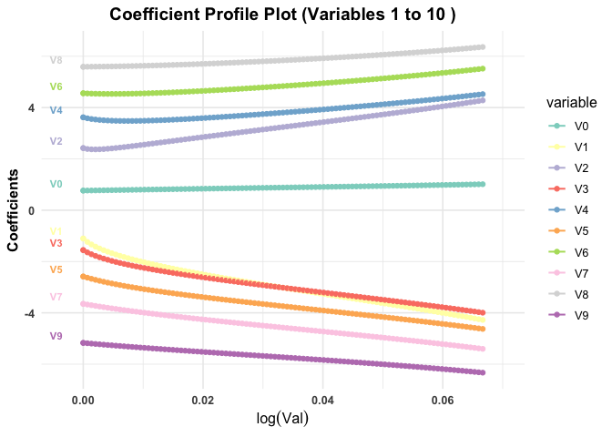

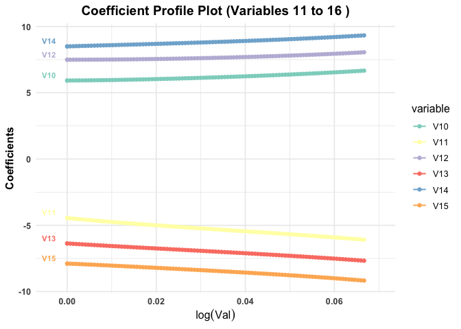

```r
# Plot the coefficient paths for cross-validation models
plot(result_pr_cv1, plot_type = "cv_coefficients", xvar = "val", max_vars_per_plot = 10, label = TRUE)
```

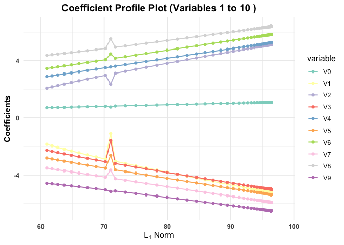

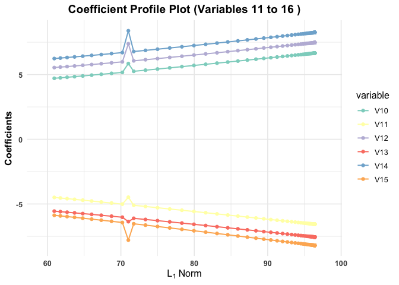

```r
# Show what happens when max_vars_per_plot exceeds the limit (will trigger a warning and reset to 10)
plot(result_pr_cv2, plot_type = "cv_coefficients", xvar = "norm", max_vars_per_plot = 12, label = FALSE)
```

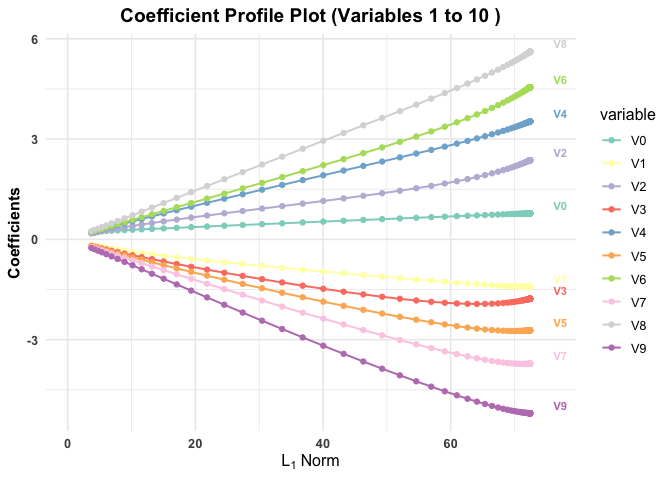

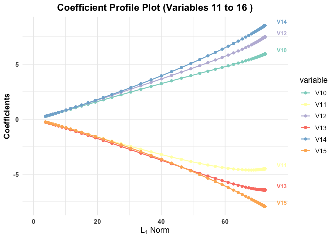

```r
# PR3 uses dual-optimization, so we can plot against lambda as well
plot(result_pr_cv3, plot_type = "cv_coefficients", xvar = "norm", max_vars_per_plot = 10, label = TRUE)
```

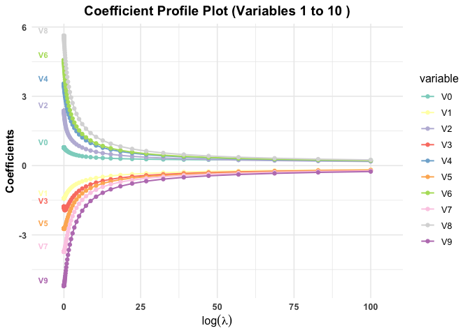

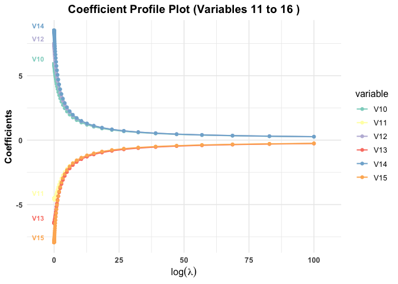

```r
plot(result_pr_cv3, plot_type = "cv_coefficients", xvar = "lambda", max_vars_per_plot = 10, label = TRUE)
```

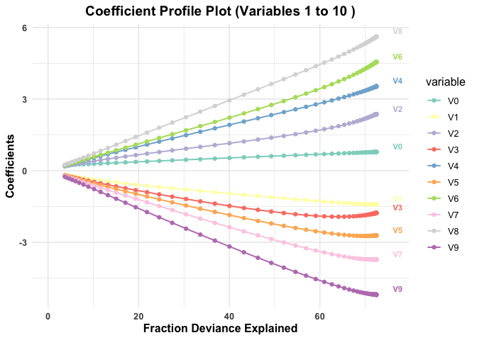

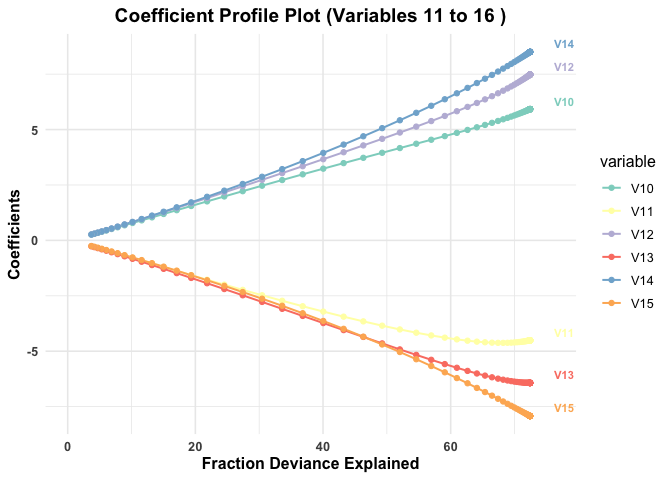

```r
plot(result_pr_cv3, plot_type = "cv_coefficients", xvar = "dev", max_vars_per_plot = 10, label = TRUE)
```

# Conclusion

This vignette has provided an overview of the main functionalities of the `savvyPR` package, covering both the Budget-based and Target-based risk parity constraints. For more details, refer to the function documentation.